# E-Commerce_PDS Project_Final_Solution_File

You have been given the role of a business analyst for an E-Commerce company and have been asked to prepare a basic report on the data. Follow the steps below for preparation of the report.

Before you start analysing the data, it is always a good practice to see the size of the data, its features and feature types. If the data set is big, it is not possible to print out all the records. </font>

#### Note: Use the markdown feature of Python to explain your answer.

## Load the necessary libraries. Import and load the dataset with a name ECom_Data .

```python
import numpy as np
import pandas as pd
import matplotlib.pyplot as plt
import seaborn as sns
pd.options.display.max_rows = 10
```

```python
# Get the Data

ECom_Data=pd.read_csv("E-Commerce_Flipkart.csv")
```

We have read the data and stored the data in "ECom_Data" variable

## Q 1. To get familiar with the data

## a) Print out the first 10 and the last 10 records of the data. (2 marks)

## b) How many rows and columns are present in the dataset? Use any two different methods to extract this information. (2 + 2 + 2 marks)

## c) How many object data types are there? (1 mark)

## d) Is there any Boolean data type? (1 mark)

#### Note: Use the markdown feature of Python to explain your answer.

#### Ans 1 a)

```python
ECom_Data.head(10)
```

|  | Customer_uniq_id | Region | Order_Date | Expected_Delivery_Date | Delivered_Date | product_name | product_main_category | product_subcategory | product_category_filter | product_category_subfilter | product_unique ID | retail_price | discounted_price | product_rating | Brand | product_specifications | description |
| --- | --- | --- | --- | --- | --- | --- | --- | --- | --- | --- | --- | --- | --- | --- | --- | --- | --- |
| 0 | c2d766ca982eca8304150849735ffef9 | North | 31-12-2021 | 03-01-2022 | 02-01-2022 | Alisha Solid Women's Cycling Shorts | Clothing | Women's Clothing | Lingerie, Sleep & Swimwear | Shorts | SRTEH2FF9KEDEFGF | 999 | 379 | 2.0 | Alisha | {"product_specification"=>[{"key"=>"Number of ... | Key Features of Alisha Solid Women's Cycling S... |
| 1 | 7f7036a6d550aaa89d34c77bd39a5e48 | East | 31-12-2021 | 03-01-2022 | 02-01-2022 | FabHomeDecor Fabric Double Sofa Bed | Furniture | Living Room Furniture | Sofa Beds & Futons | FabHomeDecor Fabric Double Sofa Bed (Finish C... | SBEEH3QGU7MFYJFY | 32157 | 22646 | 2.0 | FabHomeDecor | {"product_specification"=>[{"key"=>"Installati... | FabHomeDecor Fabric Double Sofa Bed (Finish Co... |
| 2 | f449ec65dcbc041b6ae5e6a32717d01b | East | 31-12-2021 | 03-01-2022 | 02-01-2022 | AW Bellies | Footwear | Women's Footwear | Ballerinas | AW Bellies | SHOEH4GRSUBJGZXE | 999 | 499 | 1.0 | AW | {"product_specification"=>[{"key"=>"Ideal For"... | Key Features of AW Bellies Sandals Wedges Heel... |
| 3 | 0973b37acd0c664e3de26e97e5571454 | West | 31-12-2021 | 03-01-2022 | 02-01-2022 | Alisha Solid Women's Cycling Shorts | Clothing | Women's Clothing | Lingerie, Sleep & Swimwear | Shorts | SRTEH2F6HUZMQ6SJ | 699 | 267 | 5.0 | Alisha | {"product_specification"=>[{"key"=>"Number of ... | Key Features of Alisha Solid Women's Cycling S... |
| 4 | bc940ea42ee6bef5ac7cea3fb5cfbee7 | West | 31-12-2021 | 03-01-2022 | 02-01-2022 | Sicons All Purpose Arnica Dog Shampoo | Pet Supplies | Grooming | Skin & Coat Care | Shampoo | PSOEH3ZYDMSYARJ5 | 220 | 210 | 5.0 | Sicons | {"product_specification"=>[{"key"=>"Pet Type",... | Specifications of Sicons All Purpose Arnica Do... |
| 5 | ce5a6818f7707e2cb61fdcdbba61f5ad | East | 25-12-2021 | 28-12-2021 | 27-12-2021 | Alisha Solid Women's Cycling Shorts | Clothing | Women's Clothing | Lingerie, Sleep & Swimwear | Shorts | SRTEH2FVVKRBAXHB | 1199 | 479 | 4.0 | Alisha | {"product_specification"=>[{"key"=>"Number of ... | Key Features of Alisha Solid Women's Cycling S... |
| 6 | 8542703ca9e6ebdf6d742638dfb1f2ca | East | 25-12-2021 | 28-12-2021 | 27-12-2021 | FabHomeDecor Fabric Double Sofa Bed | Furniture | Living Room Furniture | Sofa Beds & Futons | FabHomeDecor Fabric Double Sofa Bed (Finish C... | SBEEH3QGYGHFUEXN | 32157 | 22646 | 2.0 | FabHomeDecor | {"product_specification"=>[{"key"=>"Installati... | FabHomeDecor Fabric Double Sofa Bed (Finish Co... |
| 7 | 29c8d290caa451f97b1c32df64477a2c | North | 25-12-2021 | 28-12-2021 | 27-12-2021 | dilli bazaaar Bellies, Corporate Casuals, Casuals | Footwear | Women's Footwear | Ballerinas | dilli bazaaar Bellies, Corporate Casuals, Cas... | SHOEH3DZBFR88SCK | 699 | 349 | 5.0 | dilli bazaaar | {"product_specification"=>[{"key"=>"Occasion",... | Key Features of dilli bazaaar Bellies, Corpora... |
| 8 | 4044c0ac52c1ee4b28777417651faf42 | East | 25-12-2021 | 28-12-2021 | 27-12-2021 | Alisha Solid Women's Cycling Shorts | Clothing | Women's Clothing | Lingerie, Sleep & Swimwear | Shorts | SRTEH2FVUHAAVH9X | 1199 | 479 | 1.0 | Alisha | {"product_specification"=>[{"key"=>"Number of ... | Key Features of Alisha Solid Women's Cycling S... |
| 9 | e54bc0a7c3429da2ebef0b30331fe3d2 | East | 25-12-2021 | 28-12-2021 | 27-12-2021 | Ladela Bellies | Footwear | Women's Footwear | Ballerinas | Ladela Bellies | SHOEH4KM2W3Z6EH5 | 1724 | 950 | 5.0 | Ladela | {"product_specification"=>[{"key"=>"Occasion",... | Key Features of Ladela Bellies Brand: LADELA C... |

```python
ECom_Data.tail(10)
```

|  | Customer_uniq_id | Region | Order_Date | Expected_Delivery_Date | Delivered_Date | product_name | product_main_category | product_subcategory | product_category_filter | product_category_subfilter | product_unique ID | retail_price | discounted_price | product_rating | Brand | product_specifications | description |
| --- | --- | --- | --- | --- | --- | --- | --- | --- | --- | --- | --- | --- | --- | --- | --- | --- | --- |
| 8917 | 4db03bc4ccbe216cf151b2f2b904ba3f | East | 01-12-2020 | 04-12-2020 | 04-12-2020 | Luca Fashion Girls Heels | Footwear | Kids' & Infant Footwear | For Girls | Sandals | SNDEHG3DNVBFGAT5 | 999 | 499 | 4.0 | Luca Fashion | {"product_specification"=>[{"key"=>"Occasion",... | Key Features of Luca Fashion Girls Heels Occas... |
| 8918 | 4d4d6aeb13fa253499d0dd45a5abd87e | West | 01-12-2020 | 04-12-2020 | 04-12-2020 | Shoetopia Girls Sandals | Footwear | Kids' & Infant Footwear | For Girls | Sandals | SNDEG7DRWSX8HFXZ | 499 | 399 | 4.0 | Shoetopia | {"product_specification"=>[{"key"=>"Ideal For"... | Key Features of Shoetopia Girls Sandals Flats ... |
| 8919 | ea19e7ef703293d3f6c799ca9db4642d | West | 01-12-2020 | 04-12-2020 | 04-12-2020 | SMART TRADERS Girls Sandals | Footwear | Kids' & Infant Footwear | For Girls | Sandals | SNDEG7MZHHKZ58D2 | 999 | 499 | 5.0 | SMART TRADERS | {"product_specification"=>[{"key"=>"Ideal For"... | Key Features of SMART TRADERS Girls Sandals Oc... |
| 8920 | 19a53a958992fb575acffb5d41e7ef9e | East | 01-12-2020 | 04-12-2020 | 04-12-2020 | Beanz Girls Flats | Footwear | Kids' & Infant Footwear | For Girls | Sandals | SNDEG7DYVFWHZBC4 | 1299 | 1299 | 3.0 | Beanz | {"product_specification"=>[{"key"=>"Occasion",... | Key Features of Beanz Girls Flats Occasion: Ca... |
| 8921 | 09abab80c8dfdc6f268e0a6f05a0be11 | North | 01-12-2020 | 04-12-2020 | 04-12-2020 | Nova KT 728S Electric Kettle | Home & Kitchen | Kitchen Appliances | Electric Jug(heater)/Travel Kettles | Nova Electric Jug(heater)/Travel Kettles | EKTDG5C5QSADZZ8J | 3195 | 699 | 3.6 | Nova | {"product_specification"=>[{"key"=>"Brand", "v... | Specifications of Nova KT 728S Electric Kettle... |
| 8922 | 90d30478255e23621e8929ed15c2f6e4 | South | 01-12-2020 | 04-12-2020 | 04-12-2020 | Sinina Chanderi Embroidered Salwar Suit Dupatt... | Clothing | Women's Clothing | Ethnic Wear | Fabric | FABEGGHHDFMY8BZU | 2980 | 1490 | 3.0 | Sinina | {"product_specification"=>[{"key"=>"Fabric", "... | Key Features of Sinina Chanderi Embroidered Sa... |
| 8923 | 20a73e3f41490a73ceeba5f17658db8f | West | 01-12-2020 | 04-12-2020 | 04-12-2020 | Aarushi Fashion Chanderi Embroidered Salwar Su... | Clothing | Women's Clothing | Ethnic Wear | Fabric | FABEG8GFDUWRSNU3 | 2600 | 1300 | 1.0 | Aarushi Fashion | {"product_specification"=>[{"key"=>"Fabric", "... | Key Features of Aarushi Fashion Chanderi Embro... |
| 8924 | 5c1554cd45f9d538c2c6947dbdd59c75 | East | 01-12-2020 | 04-12-2020 | 04-12-2020 | Ambika Lahenga Embroidered Lehenga, Choli and ... | Clothing | Women's Clothing | Ethnic Wear | Lehenga Cholis | LEHEGGEHYN4G2RPW | 39992 | 24995 | 1.0 | Ambika Lahenga | {"product_specification"=>[{"key"=>"Fabric", "... | Key Features of Ambika Lahenga Embroidered Leh... |
| 8925 | 6b737a4deca1ed0e56c179e66036e994 | West | 01-12-2020 | 04-12-2020 | 04-12-2020 | Sinina Chanderi Embroidered Salwar Suit Dupatt... | Clothing | Women's Clothing | Ethnic Wear | Fabric | FABEGGHHGSVCHGFV | 2000 | 1000 | 3.0 | Sinina | {"product_specification"=>[{"key"=>"Fabric", "... | Key Features of Sinina Chanderi Embroidered Sa... |
| 8926 | a5235ac28d3d5487f54025f9d6b57433 | North | 01-12-2020 | 04-12-2020 | 04-12-2020 | Aarushi Fashion Silk Striped Salwar Suit Dupat... | Clothing | Women's Clothing | Ethnic Wear | Fabric | FABEG8GYDAABECZH | 2800 | 1350 | 4.0 | Aarushi Fashion | {"product_specification"=>[{"key"=>"Fabric", "... | Key Features of Aarushi Fashion Silk Striped S... |

#### Ans 1 b)

```python
# First way
ECom_Data.info()
```

```
<class 'pandas.core.frame.DataFrame'>
RangeIndex: 8927 entries, 0 to 8926
Data columns (total 17 columns):
 #   Column                      Non-Null Count  Dtype
---  ------                      --------------  -----
 0   Customer_uniq_id            8927 non-null   object
 1   Region                      8927 non-null   object
 2   Order_Date                  8927 non-null   object
 3   Expected_Delivery_Date      8927 non-null   object
 4   Delivered_Date              8927 non-null   object
 5   product_name                8927 non-null   object
 6   product_main_category       8927 non-null   object
 7   product_subcategory         8927 non-null   object
 8   product_category_filter     8927 non-null   object
 9   product_category_subfilter  8927 non-null   object
 10  product_unique ID           8927 non-null   object
 11  retail_price                8927 non-null   int64
 12  discounted_price            8927 non-null   int64
 13  product_rating              8927 non-null   float64
 14  Brand                       8927 non-null   object
 15  product_specifications      8927 non-null   object
 16  description                 8927 non-null   object
dtypes: float64(1), int64(2), object(14)
memory usage: 1.2+ MB
```

```python
# second way
ECom_Data.shape
```

```
(8927, 17)
```

#### ECom_Data.info() & ECom_Data.shape can be used to get the total number of rows & columns. Here we have 8927 rows & 17 columns

#### Ans 1 c)

```python
ECom_Data.info()
```

```
<class 'pandas.core.frame.DataFrame'>
RangeIndex: 8927 entries, 0 to 8926
Data columns (total 17 columns):
 #   Column                      Non-Null Count  Dtype
---  ------                      --------------  -----
 0   Customer_uniq_id            8927 non-null   object
 1   Region                      8927 non-null   object
 2   Order_Date                  8927 non-null   object
 3   Expected_Delivery_Date      8927 non-null   object
 4   Delivered_Date              8927 non-null   object
 5   product_name                8927 non-null   object
 6   product_main_category       8927 non-null   object
 7   product_subcategory         8927 non-null   object
 8   product_category_filter     8927 non-null   object
 9   product_category_subfilter  8927 non-null   object
 10  product_unique ID           8927 non-null   object
 11  retail_price                8927 non-null   int64
 12  discounted_price            8927 non-null   int64
 13  product_rating              8927 non-null   float64
 14  Brand                       8927 non-null   object
 15  product_specifications      8927 non-null   object
 16  description                 8927 non-null   object
dtypes: float64(1), int64(2), object(14)
memory usage: 1.2+ MB
```

#### There are 14 object dtypes which we obtained using ECom_Data.info() from previous Question

#### Ans 1 d)

#### No, there is NO boolean data type in the dataset

Once you are familiar with the data, you may decide that not all features are of use to you and you may want to delete the non-informative features (columns)

## Q 2. Eliminating the non-informative columns.

## a) Drop the columns product_specifications and description. (2 marks)

## b) Which method or function is used to permanently delete the columns mentioned in part (a)? Write the code explicitly (2 marks)

### Note: Use the markdown feature of Python to explain your answer.

### Ans 2 a)

```python
ECom_Data.drop(['product_specifications','description'],axis=1)
```

|  | Customer_uniq_id | Region | Order_Date | Expected_Delivery_Date | Delivered_Date | product_name | product_main_category | product_subcategory | product_category_filter | product_category_subfilter | product_unique ID | retail_price | discounted_price | product_rating | Brand |
| --- | --- | --- | --- | --- | --- | --- | --- | --- | --- | --- | --- | --- | --- | --- | --- |
| 0 | c2d766ca982eca8304150849735ffef9 | North | 31-12-2021 | 03-01-2022 | 02-01-2022 | Alisha Solid Women's Cycling Shorts | Clothing | Women's Clothing | Lingerie, Sleep & Swimwear | Shorts | SRTEH2FF9KEDEFGF | 999 | 379 | 2.0 | Alisha |
| 1 | 7f7036a6d550aaa89d34c77bd39a5e48 | East | 31-12-2021 | 03-01-2022 | 02-01-2022 | FabHomeDecor Fabric Double Sofa Bed | Furniture | Living Room Furniture | Sofa Beds & Futons | FabHomeDecor Fabric Double Sofa Bed (Finish C... | SBEEH3QGU7MFYJFY | 32157 | 22646 | 2.0 | FabHomeDecor |
| 2 | f449ec65dcbc041b6ae5e6a32717d01b | East | 31-12-2021 | 03-01-2022 | 02-01-2022 | AW Bellies | Footwear | Women's Footwear | Ballerinas | AW Bellies | SHOEH4GRSUBJGZXE | 999 | 499 | 1.0 | AW |
| 3 | 0973b37acd0c664e3de26e97e5571454 | West | 31-12-2021 | 03-01-2022 | 02-01-2022 | Alisha Solid Women's Cycling Shorts | Clothing | Women's Clothing | Lingerie, Sleep & Swimwear | Shorts | SRTEH2F6HUZMQ6SJ | 699 | 267 | 5.0 | Alisha |
| 4 | bc940ea42ee6bef5ac7cea3fb5cfbee7 | West | 31-12-2021 | 03-01-2022 | 02-01-2022 | Sicons All Purpose Arnica Dog Shampoo | Pet Supplies | Grooming | Skin & Coat Care | Shampoo | PSOEH3ZYDMSYARJ5 | 220 | 210 | 5.0 | Sicons |
| ... | ... | ... | ... | ... | ... | ... | ... | ... | ... | ... | ... | ... | ... | ... | ... |
| 8922 | 90d30478255e23621e8929ed15c2f6e4 | South | 01-12-2020 | 04-12-2020 | 04-12-2020 | Sinina Chanderi Embroidered Salwar Suit Dupatt... | Clothing | Women's Clothing | Ethnic Wear | Fabric | FABEGGHHDFMY8BZU | 2980 | 1490 | 3.0 | Sinina |
| 8923 | 20a73e3f41490a73ceeba5f17658db8f | West | 01-12-2020 | 04-12-2020 | 04-12-2020 | Aarushi Fashion Chanderi Embroidered Salwar Su... | Clothing | Women's Clothing | Ethnic Wear | Fabric | FABEG8GFDUWRSNU3 | 2600 | 1300 | 1.0 | Aarushi Fashion |
| 8924 | 5c1554cd45f9d538c2c6947dbdd59c75 | East | 01-12-2020 | 04-12-2020 | 04-12-2020 | Ambika Lahenga Embroidered Lehenga, Choli and ... | Clothing | Women's Clothing | Ethnic Wear | Lehenga Cholis | LEHEGGEHYN4G2RPW | 39992 | 24995 | 1.0 | Ambika Lahenga |
| 8925 | 6b737a4deca1ed0e56c179e66036e994 | West | 01-12-2020 | 04-12-2020 | 04-12-2020 | Sinina Chanderi Embroidered Salwar Suit Dupatt... | Clothing | Women's Clothing | Ethnic Wear | Fabric | FABEGGHHGSVCHGFV | 2000 | 1000 | 3.0 | Sinina |
| 8926 | a5235ac28d3d5487f54025f9d6b57433 | North | 01-12-2020 | 04-12-2020 | 04-12-2020 | Aarushi Fashion Silk Striped Salwar Suit Dupat... | Clothing | Women's Clothing | Ethnic Wear | Fabric | FABEG8GYDAABECZH | 2800 | 1350 | 4.0 | Aarushi Fashion |

8927 rows × 15 columns

```python
ECom_Data
```

|  | Customer_uniq_id | Region | Order_Date | Expected_Delivery_Date | Delivered_Date | product_name | product_main_category | product_subcategory | product_category_filter | product_category_subfilter | product_unique ID | retail_price | discounted_price | product_rating | Brand | product_specifications | description |
| --- | --- | --- | --- | --- | --- | --- | --- | --- | --- | --- | --- | --- | --- | --- | --- | --- | --- |
| 0 | c2d766ca982eca8304150849735ffef9 | North | 31-12-2021 | 03-01-2022 | 02-01-2022 | Alisha Solid Women's Cycling Shorts | Clothing | Women's Clothing | Lingerie, Sleep & Swimwear | Shorts | SRTEH2FF9KEDEFGF | 999 | 379 | 2.0 | Alisha | {"product_specification"=>[{"key"=>"Number of ... | Key Features of Alisha Solid Women's Cycling S... |
| 1 | 7f7036a6d550aaa89d34c77bd39a5e48 | East | 31-12-2021 | 03-01-2022 | 02-01-2022 | FabHomeDecor Fabric Double Sofa Bed | Furniture | Living Room Furniture | Sofa Beds & Futons | FabHomeDecor Fabric Double Sofa Bed (Finish C... | SBEEH3QGU7MFYJFY | 32157 | 22646 | 2.0 | FabHomeDecor | {"product_specification"=>[{"key"=>"Installati... | FabHomeDecor Fabric Double Sofa Bed (Finish Co... |
| 2 | f449ec65dcbc041b6ae5e6a32717d01b | East | 31-12-2021 | 03-01-2022 | 02-01-2022 | AW Bellies | Footwear | Women's Footwear | Ballerinas | AW Bellies | SHOEH4GRSUBJGZXE | 999 | 499 | 1.0 | AW | {"product_specification"=>[{"key"=>"Ideal For"... | Key Features of AW Bellies Sandals Wedges Heel... |
| 3 | 0973b37acd0c664e3de26e97e5571454 | West | 31-12-2021 | 03-01-2022 | 02-01-2022 | Alisha Solid Women's Cycling Shorts | Clothing | Women's Clothing | Lingerie, Sleep & Swimwear | Shorts | SRTEH2F6HUZMQ6SJ | 699 | 267 | 5.0 | Alisha | {"product_specification"=>[{"key"=>"Number of ... | Key Features of Alisha Solid Women's Cycling S... |
| 4 | bc940ea42ee6bef5ac7cea3fb5cfbee7 | West | 31-12-2021 | 03-01-2022 | 02-01-2022 | Sicons All Purpose Arnica Dog Shampoo | Pet Supplies | Grooming | Skin & Coat Care | Shampoo | PSOEH3ZYDMSYARJ5 | 220 | 210 | 5.0 | Sicons | {"product_specification"=>[{"key"=>"Pet Type",... | Specifications of Sicons All Purpose Arnica Do... |
| ... | ... | ... | ... | ... | ... | ... | ... | ... | ... | ... | ... | ... | ... | ... | ... | ... | ... |
| 8922 | 90d30478255e23621e8929ed15c2f6e4 | South | 01-12-2020 | 04-12-2020 | 04-12-2020 | Sinina Chanderi Embroidered Salwar Suit Dupatt... | Clothing | Women's Clothing | Ethnic Wear | Fabric | FABEGGHHDFMY8BZU | 2980 | 1490 | 3.0 | Sinina | {"product_specification"=>[{"key"=>"Fabric", "... | Key Features of Sinina Chanderi Embroidered Sa... |
| 8923 | 20a73e3f41490a73ceeba5f17658db8f | West | 01-12-2020 | 04-12-2020 | 04-12-2020 | Aarushi Fashion Chanderi Embroidered Salwar Su... | Clothing | Women's Clothing | Ethnic Wear | Fabric | FABEG8GFDUWRSNU3 | 2600 | 1300 | 1.0 | Aarushi Fashion | {"product_specification"=>[{"key"=>"Fabric", "... | Key Features of Aarushi Fashion Chanderi Embro... |
| 8924 | 5c1554cd45f9d538c2c6947dbdd59c75 | East | 01-12-2020 | 04-12-2020 | 04-12-2020 | Ambika Lahenga Embroidered Lehenga, Choli and ... | Clothing | Women's Clothing | Ethnic Wear | Lehenga Cholis | LEHEGGEHYN4G2RPW | 39992 | 24995 | 1.0 | Ambika Lahenga | {"product_specification"=>[{"key"=>"Fabric", "... | Key Features of Ambika Lahenga Embroidered Leh... |
| 8925 | 6b737a4deca1ed0e56c179e66036e994 | West | 01-12-2020 | 04-12-2020 | 04-12-2020 | Sinina Chanderi Embroidered Salwar Suit Dupatt... | Clothing | Women's Clothing | Ethnic Wear | Fabric | FABEGGHHGSVCHGFV | 2000 | 1000 | 3.0 | Sinina | {"product_specification"=>[{"key"=>"Fabric", "... | Key Features of Sinina Chanderi Embroidered Sa... |
| 8926 | a5235ac28d3d5487f54025f9d6b57433 | North | 01-12-2020 | 04-12-2020 | 04-12-2020 | Aarushi Fashion Silk Striped Salwar Suit Dupat... | Clothing | Women's Clothing | Ethnic Wear | Fabric | FABEG8GYDAABECZH | 2800 | 1350 | 4.0 | Aarushi Fashion | {"product_specification"=>[{"key"=>"Fabric", "... | Key Features of Aarushi Fashion Silk Striped S... |

8927 rows × 17 columns

### Ans 2 b)

```python
ECom_Data.drop(['product_specifications','description'],axis=1, inplace=True)
```

```python
ECom_Data
```

|  | Customer_uniq_id | Region | Order_Date | Expected_Delivery_Date | Delivered_Date | product_name | product_main_category | product_subcategory | product_category_filter | product_category_subfilter | product_unique ID | retail_price | discounted_price | product_rating | Brand |
| --- | --- | --- | --- | --- | --- | --- | --- | --- | --- | --- | --- | --- | --- | --- | --- |
| 0 | c2d766ca982eca8304150849735ffef9 | North | 31-12-2021 | 03-01-2022 | 02-01-2022 | Alisha Solid Women's Cycling Shorts | Clothing | Women's Clothing | Lingerie, Sleep & Swimwear | Shorts | SRTEH2FF9KEDEFGF | 999 | 379 | 2.0 | Alisha |
| 1 | 7f7036a6d550aaa89d34c77bd39a5e48 | East | 31-12-2021 | 03-01-2022 | 02-01-2022 | FabHomeDecor Fabric Double Sofa Bed | Furniture | Living Room Furniture | Sofa Beds & Futons | FabHomeDecor Fabric Double Sofa Bed (Finish C... | SBEEH3QGU7MFYJFY | 32157 | 22646 | 2.0 | FabHomeDecor |
| 2 | f449ec65dcbc041b6ae5e6a32717d01b | East | 31-12-2021 | 03-01-2022 | 02-01-2022 | AW Bellies | Footwear | Women's Footwear | Ballerinas | AW Bellies | SHOEH4GRSUBJGZXE | 999 | 499 | 1.0 | AW |
| 3 | 0973b37acd0c664e3de26e97e5571454 | West | 31-12-2021 | 03-01-2022 | 02-01-2022 | Alisha Solid Women's Cycling Shorts | Clothing | Women's Clothing | Lingerie, Sleep & Swimwear | Shorts | SRTEH2F6HUZMQ6SJ | 699 | 267 | 5.0 | Alisha |
| 4 | bc940ea42ee6bef5ac7cea3fb5cfbee7 | West | 31-12-2021 | 03-01-2022 | 02-01-2022 | Sicons All Purpose Arnica Dog Shampoo | Pet Supplies | Grooming | Skin & Coat Care | Shampoo | PSOEH3ZYDMSYARJ5 | 220 | 210 | 5.0 | Sicons |
| ... | ... | ... | ... | ... | ... | ... | ... | ... | ... | ... | ... | ... | ... | ... | ... |
| 8922 | 90d30478255e23621e8929ed15c2f6e4 | South | 01-12-2020 | 04-12-2020 | 04-12-2020 | Sinina Chanderi Embroidered Salwar Suit Dupatt... | Clothing | Women's Clothing | Ethnic Wear | Fabric | FABEGGHHDFMY8BZU | 2980 | 1490 | 3.0 | Sinina |
| 8923 | 20a73e3f41490a73ceeba5f17658db8f | West | 01-12-2020 | 04-12-2020 | 04-12-2020 | Aarushi Fashion Chanderi Embroidered Salwar Su... | Clothing | Women's Clothing | Ethnic Wear | Fabric | FABEG8GFDUWRSNU3 | 2600 | 1300 | 1.0 | Aarushi Fashion |
| 8924 | 5c1554cd45f9d538c2c6947dbdd59c75 | East | 01-12-2020 | 04-12-2020 | 04-12-2020 | Ambika Lahenga Embroidered Lehenga, Choli and ... | Clothing | Women's Clothing | Ethnic Wear | Lehenga Cholis | LEHEGGEHYN4G2RPW | 39992 | 24995 | 1.0 | Ambika Lahenga |
| 8925 | 6b737a4deca1ed0e56c179e66036e994 | West | 01-12-2020 | 04-12-2020 | 04-12-2020 | Sinina Chanderi Embroidered Salwar Suit Dupatt... | Clothing | Women's Clothing | Ethnic Wear | Fabric | FABEGGHHGSVCHGFV | 2000 | 1000 | 3.0 | Sinina |
| 8926 | a5235ac28d3d5487f54025f9d6b57433 | North | 01-12-2020 | 04-12-2020 | 04-12-2020 | Aarushi Fashion Silk Striped Salwar Suit Dupat... | Clothing | Women's Clothing | Ethnic Wear | Fabric | FABEG8GYDAABECZH | 2800 | 1350 | 4.0 | Aarushi Fashion |

8927 rows × 15 columns

#### inplace=True is used to permanently remove the columns from the original dataset

The next steps in this project involves summarization of data at various levels and visualization. Such apparently simple steps are very useful to get an overall sense of the data.

## Q 3. Here we summarize the data at Brand level.

## a) How many unique Brand are there? (2 marks)

## b) Note that each Brand contains multiple products. Show the average product_rating within each Brand (2 marks)

### Ans 3 a)

```python
ECom_Data['Brand'].unique()
ECom_Data['Brand'].value_counts()
```

```
Allure Auto     469
Regular         299
Slim            267
TheLostPuppy    229
Black           147
               ...
Nirlon            1
Blinkin           1
Goyal India       1
Safari Ltd.       1
SM Nutrition      1
Name: Brand, Length: 2580, dtype: int64
```

## OR

```python
ECom_Data['Brand'].nunique()
```

```
2580
```

#### There are 2580 unique brands

### Ans 3 b)

```python
ECom_Data.groupby(['Brand'])['product_rating'].mean()
```

```
Brand
1OAK            1.500000
3A AUTOCARE     3.268293
3D Mat          3.000000
3kFactory       2.000000
4D              3.600000
                  ...
youniqueshop    2.000000
zDelhi.com      5.000000
zaidis          4.000000
zasmina         4.500000
 Tarkan         5.000000
Name: product_rating, Length: 2580, dtype: float64
```

## Q 4. Next we study the main categories of the products.

## a) Create an appropriate plot to show the count of items ordered for each product_main_category. (6 marks).

### Hint: Create a bar chart titled "Product Category type" where product_main_category are on x-axis and counts are on y-axis.

### Note: Both axis labels, i.e. the names of the product_main_category and counts must be clearly legible.

## b) From the plot identify for which two product_main_category(s) maximum and minimum orders were placed. (2 marks)

## c) Write code to print out the top 5 product_main_category(s) in descending order? (3 marks

### Ans 4 a)

```python
ECom_Data['product_main_category'].value_counts().shape
```

```
(26,)
```

```python
ECom_Data['product_main_category'].value_counts()
```

```
Clothing                       2952
Mobiles & Accessories          1084
Automotive                     1001
Home Decor & Festive Needs      727
Computers                       558
                               ...
Pet Supplies                     22
Home Entertainment               17
Household Supplies                4
Food & Nutrition                  2
Wearable Smart Devices            1
Name: product_main_category, Length: 26, dtype: int64
```

[output not shown]

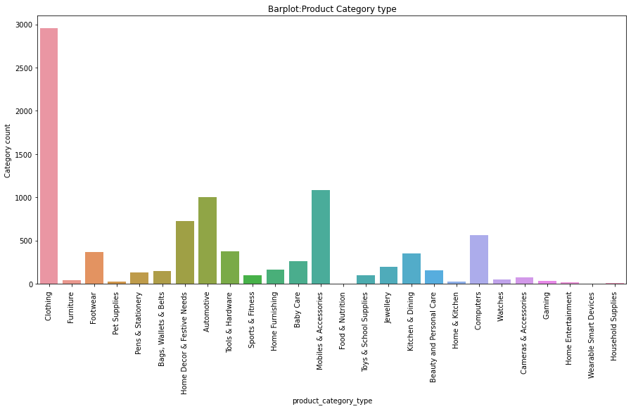

```python
plt.figure(figsize=(15,7))
plt.title('Barplot:Product Category type')
sns.countplot(data= ECom_Data, x='product_main_category')
plt.xlabel('product_category_type');
plt.ylabel('Category count');
plt.xticks(rotation=90)
```

### Ans 4 b)

#### The maximum orders were placed for Clothing whereas minimum orders were placed for Wearable Smart Devices.

### Ans 4 c)

```python
ECom_Data['product_main_category'].value_counts()[:5]
```

```
Clothing                       2952
Mobiles & Accessories          1084
Automotive                     1001
Home Decor & Festive Needs      727
Computers                       558
Name: product_main_category, dtype: int64
```

In E-commerce, both the retailers (here brands) and the company have to make profit to sustain in the business. The E-Commerce company has the following rule for computing their own revenue:

#### (i) 25% on the orders having final price (discounted price) greater than 600

#### (ii) 15% on the orders having final price (discounted price) greater than 350 but less than or equal to 600

#### (iii) 10% on the orders having final price (discounted price) greater than 100 but less than or equal to 350

#### (iv) Otherwise, 5% on the final price (discounted price) </font>

## Q 5. Find the net revenue generated by the E-Commerce company over all orders placed. (6 marks)

### Ans 5

```python
#function to determine the net revenue
def compute_rev(x):
    if x > 600:
        return x*0.25
    elif x > 350:
        return x*0.15
    elif x > 100:
        return x*0.10
    else:
        return x*0.05

ECom_Data['Revenue'] = ECom_Data['discounted_price'].apply(compute_rev)
ECom_Data.head()
```

|  | Customer_uniq_id | Region | Order_Date | Expected_Delivery_Date | Delivered_Date | product_name | product_main_category | product_subcategory | product_category_filter | product_category_subfilter | product_unique ID | retail_price | discounted_price | product_rating | Brand | Revenue |
| --- | --- | --- | --- | --- | --- | --- | --- | --- | --- | --- | --- | --- | --- | --- | --- | --- |
| 0 | c2d766ca982eca8304150849735ffef9 | North | 31-12-2021 | 03-01-2022 | 02-01-2022 | Alisha Solid Women's Cycling Shorts | Clothing | Women's Clothing | Lingerie, Sleep & Swimwear | Shorts | SRTEH2FF9KEDEFGF | 999 | 379 | 2.0 | Alisha | 56.85 |
| 1 | 7f7036a6d550aaa89d34c77bd39a5e48 | East | 31-12-2021 | 03-01-2022 | 02-01-2022 | FabHomeDecor Fabric Double Sofa Bed | Furniture | Living Room Furniture | Sofa Beds & Futons | FabHomeDecor Fabric Double Sofa Bed (Finish C... | SBEEH3QGU7MFYJFY | 32157 | 22646 | 2.0 | FabHomeDecor | 5661.50 |
| 2 | f449ec65dcbc041b6ae5e6a32717d01b | East | 31-12-2021 | 03-01-2022 | 02-01-2022 | AW Bellies | Footwear | Women's Footwear | Ballerinas | AW Bellies | SHOEH4GRSUBJGZXE | 999 | 499 | 1.0 | AW | 74.85 |
| 3 | 0973b37acd0c664e3de26e97e5571454 | West | 31-12-2021 | 03-01-2022 | 02-01-2022 | Alisha Solid Women's Cycling Shorts | Clothing | Women's Clothing | Lingerie, Sleep & Swimwear | Shorts | SRTEH2F6HUZMQ6SJ | 699 | 267 | 5.0 | Alisha | 26.70 |
| 4 | bc940ea42ee6bef5ac7cea3fb5cfbee7 | West | 31-12-2021 | 03-01-2022 | 02-01-2022 | Sicons All Purpose Arnica Dog Shampoo | Pet Supplies | Grooming | Skin & Coat Care | Shampoo | PSOEH3ZYDMSYARJ5 | 220 | 210 | 5.0 | Sicons | 21.00 |

```python
# get the total revenue and print it
total_rev = ECom_Data['Revenue'].sum()
print('The net revenue generated by the ECom company across all orders is', total_rev, 'rupees')
```

```
The net revenue generated by the ECom company across all orders is 2242221.75 rupees
```

Now you need to find the revenue for each retailer (Brand)

#### Hint: Net BrandRevenue is BrandRevenue which is generated after all the deductions. Also, BrandRevenue is different from the E-Commerce company's net revenue.

### Ans 6

```python
ECom_Data['BrandRevenue']= ECom_Data['discounted_price']-ECom_Data['Revenue']
ECom_Data.groupby(['Brand'])['BrandRevenue'].sum().sort_values(ascending = False).head(10)
```

```
Brand
Allure Auto     498464.25
GAGA            237390.00
Slim            212062.60
DailyObjects    181980.00
Diviniti        143115.00
Regular         126112.35
Enthopia        123146.25
TheLostPuppy    116595.35
Asus             99241.50
Springwel        88978.50
Name: BrandRevenue, dtype: float64
```

Let us now investigate multiple features for each product to determine any pattern.

## Q 7. Compare prices for each product.

## a) Draw boxplots of retail_price & discounted_price. (3 marks)

## b) Are there any outliers? (Yes/No) (1mark)

## c) Create a scatterplot of retail_price (x-axis) and discounted_price (y-axis) (3 marks)

### Ans 7 a)

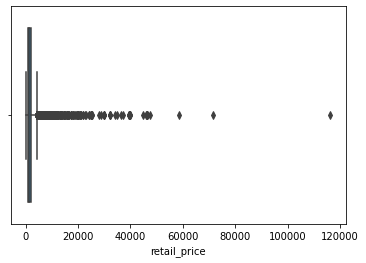

```python
sns.boxplot(data=ECom_Data, x='retail_price');
```

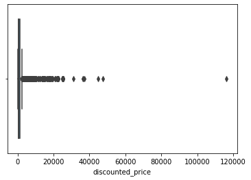

```python
sns.boxplot(data=ECom_Data, x='discounted_price');
```

### Ans 7 b)

#### Yes, there are outliers in the data

### Ans 7 c)

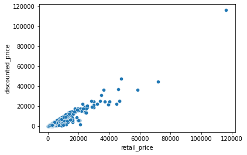

```python
sns.scatterplot(data=ECom_Data, x='retail_price', y='discounted_price');
```

The next steps will enable to study brand-level information.

## Q 8. Create a new dataframe to include the Brand specific information as stated:

## i. total number of orders placed per Brand

## ii. total retail_price per Brand

## iii. total discounted_price per Brand, and

## iv. total net BrandRevenue generated per Brand.

## Also, draw a pairplot using these four features. (6 marks)

### Ans 8

```python
#Total number of orders placed per brand
NoOfOrders=ECom_Data['Brand'].value_counts()
print(NoOfOrders)
```

```
Allure Auto     469
Regular         299
Slim            267
TheLostPuppy    229
Black           147
               ...
Nirlon            1
Blinkin           1
Goyal India       1
Safari Ltd.       1
SM Nutrition      1
Name: Brand, Length: 2580, dtype: int64
```

```python
#total retail_price per brand
RetailPriceBrandWise=ECom_Data.groupby(['Brand'])['retail_price'].sum()
print(RetailPriceBrandWise)
```

```
Brand
1OAK              1698
3A AUTOCARE     107059
3D Mat            7250
3kFactory          399
4D               17500
                 ...
youniqueshop       810
zDelhi.com        4499
zaidis             150
zasmina           1400
 Tarkan           1999
Name: retail_price, Length: 2580, dtype: int64
```

```python
# total discount_price per brand
DiscountPriceBrandWise=ECom_Data.groupby(['Brand'])['discounted_price'].sum()
print(DiscountPriceBrandWise)
```

```
Brand
1OAK             1274
3A AUTOCARE     74134
3D Mat           6999
3kFactory         174
4D               7948
                ...
youniqueshop      640
zDelhi.com       3999
zaidis            129
zasmina           639
 Tarkan           349
Name: discounted_price, Length: 2580, dtype: int64
```

```python
#total BrandRevenue generated per brand.
BrandRevenueFinal=ECom_Data.groupby(['Brand'])['BrandRevenue'].sum().sort_values(ascending = False)
```

```python
DF_New=pd.DataFrame(columns=['RetailPriceBrandWise','NoOfOrders','DiscountPriceBrandWise', 'BrandRevenueFinal'])
DF_New['RetailPriceBrandWise']=RetailPriceBrandWise
DF_New['NoOfOrders']=NoOfOrders
DF_New['DiscountPriceBrandWise']=DiscountPriceBrandWise
DF_New['BrandRevenueFinal']=BrandRevenueFinal
DF_New
```

| Brand | RetailPriceBrandWise | NoOfOrders | DiscountPriceBrandWise | BrandRevenueFinal |
| --- | --- | --- | --- | --- |
| 1OAK | 1698 | 2 | 1274 | 1015.40 |
| 3A AUTOCARE | 107059 | 41 | 74134 | 55647.90 |
| 3D Mat | 7250 | 1 | 6999 | 5249.25 |
| 3kFactory | 399 | 1 | 174 | 156.60 |
| 4D | 17500 | 5 | 7948 | 5961.00 |
| ... | ... | ... | ... | ... |
| youniqueshop | 810 | 1 | 640 | 480.00 |
| zDelhi.com | 4499 | 1 | 3999 | 2999.25 |
| zaidis | 150 | 1 | 129 | 116.10 |
| zasmina | 1400 | 2 | 639 | 575.10 |
| Tarkan | 1999 | 1 | 349 | 314.10 |

2580 rows × 4 columns

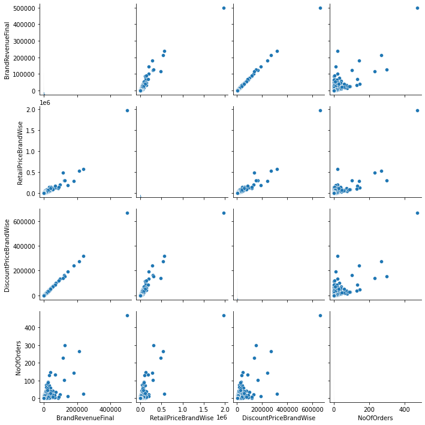

```python
plt.figure(figsize=(16,10))
sns.pairplot(data=DF_New[['BrandRevenueFinal','RetailPriceBrandWise','DiscountPriceBrandWise','NoOfOrders']])
```

The E-Commerce company operate in multiple regions. It is important to understand its performance in each region.

## Q 9.Compare performance regionwise

## a) Draw a lineplot for the monthly net Revenue of E-Commerce Company for each region separately. (4 marks)

## b) Identify the best and the worst performing months for each region. (2 marks)

#### Note: Only those days with actual orders (Order_Date) placed are present in the dataset. Assuming there were no orders on other days

### Ans 9 a)

```python
pd.options.mode.chained_assignment = None  # default='warning '
ECom_Data['Order_Date']  = pd.to_datetime(ECom_Data['Order_Date'],dayfirst=True)
```

```python
ECom_Data['Order_Date'].dt.strftime('%d-%m-%y')
```

```
0       31-12-21
1       31-12-21
2       31-12-21
3       31-12-21
4       31-12-21
          ...
8922    01-12-20
8923    01-12-20
8924    01-12-20
8925    01-12-20
8926    01-12-20
Name: Order_Date, Length: 8927, dtype: object
```

```python
ECom_Data['months'] = ECom_Data['Order_Date'].dt.month
```

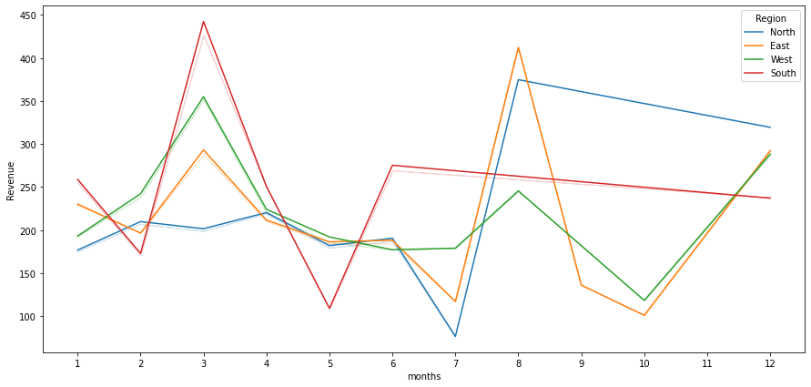

```python
plt.figure(figsize = (15,7))
#plt.xticks(np.arange(0, len('months')+7, 1))
#plt.xlim(1, 12)
plt.xticks(np.arange(0,13,1))
sns.lineplot(data=ECom_Data,x = 'months' , y = 'Revenue', ci = False ,hue='Region');
```

### Ans 9 b)

#### North region outperformed in the month of August , however it generated least Revenue in July month

#### East region outperformed in the month of August , however it generated least Revenue in October month

#### West region outperformed in the month of March , however it generated least Revenue in October month

#### South region outperformed in the month of March , however it generated least Revenue in May month

Congratulations! You have learnt how to approach a complex data and extract information out of it.